# Simple Data Exploration [R]

Philipp Spachtholz

May, 2017

This is a simple EDA for the Sberbank data set.

- Sale Price
- Association of Variables with Sale Price
- Timestamp
- Interactive Time Plot
- Total Area
- Living Area
- Kitchen Area
- Number of Living Rooms
- Build year
- Floor
- Max Floor
- Floor/Max Floor
- Appartment State
- Wall Material
- Product Type

There are a number of outliers in some variables. Therefore I first plotted the complete data, to get a first impression and then I zoomed into the relevant part of the data distributions.

The tabbed plotting approach is inspired by [this kernel](https://www.kaggle.com/damianpanek/data-exploration-in-r) from Damiano

## Sale Price

### Complete (with Outliers)

We can see two interesting things: 1) The distribution is skewed and 2) it has quite a long tail.

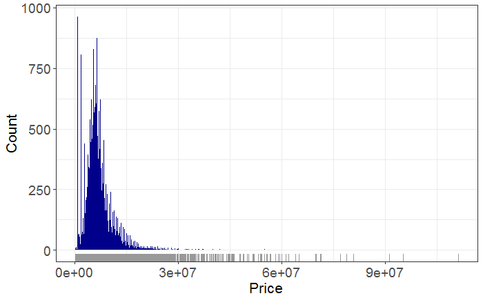

### Zoomed

When zooming closer one can clearly see the two spikes on the left side of the distribution. These seem to be popular sale prices. It might be worthwile, to later round predicted prices which are close to these values to exactly match these values.

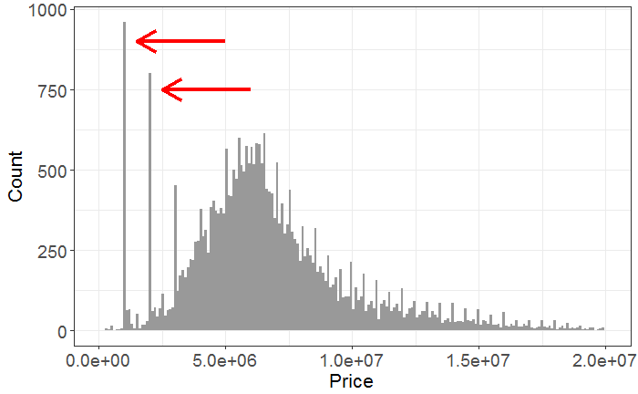

### Log Price

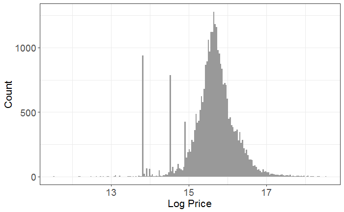

## Association of Variables with Sale Price

### Timestamp

Let’s first see, whether the sale price varies with the time point when the property was sold.

#### Per Year

We can see a clear upward trend across the recent years.

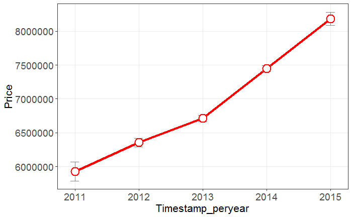

#### Per Month

The monthly plot does not provide a lot of additional information beyond the trend across years. Maybe from 2012 to 2013 there is an effect of month.

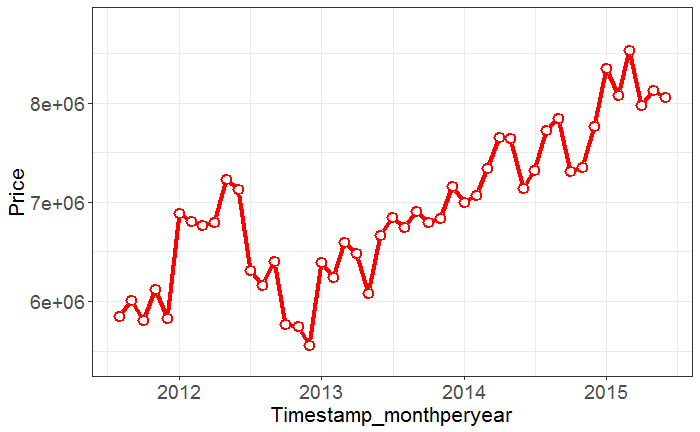

#### Per Day

Hard to see anything in this plot.

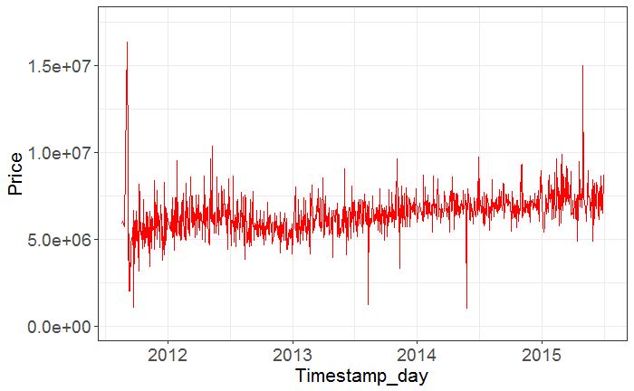

### Per day

#### Moving Average Plot

It is hard to get anything from the ‘per day’ plot above, because the resolution of a static plot is not good enough. So here is a interactive plot using [dygraphs](http://rstudio.github.io/dygraphs/).

Still the time series plot is quite spiky so I decided to apply a moving average filter.

[interactive chart not shown]

### Seasonal effects

These plot check the possibility that there might be a trend across the year, e.g. seasonal effects.

#### Per Month

Prices in the first half of the year seem a little higher than in the second half of the year.

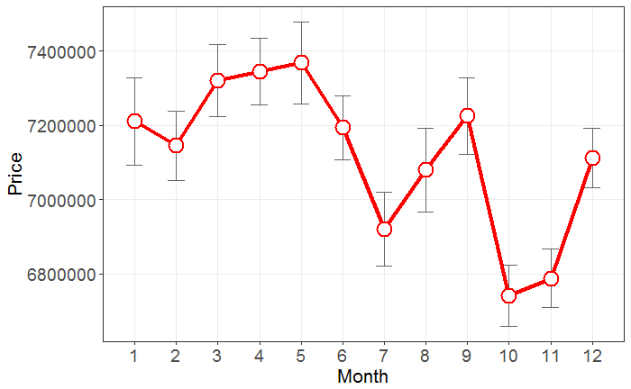

The trend of higher prices in the first half of the year might actually be driven by the year 2012, where we saw an effect of month in the “per month”-Plot above. So excluding this year from the plot we see that the monthly trend is not as pronounced as it was before.

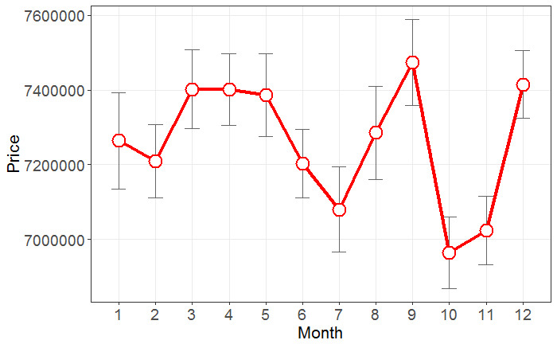

#### Per Day of Month

Within a month the day does not really have an effect on the sale price.

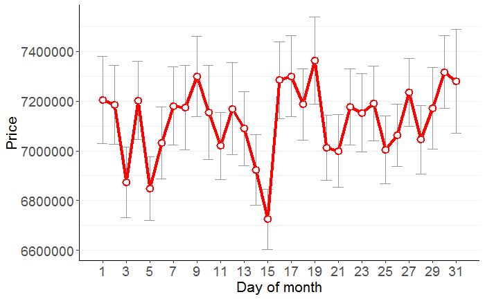

#### Per Day of Week

It seems like selling a house on a weekend (sunday 1, saturday 7) is not a good idea. Thanks for suggesting this idea to [Alexander](https://www.kaggle.com/abogdan).

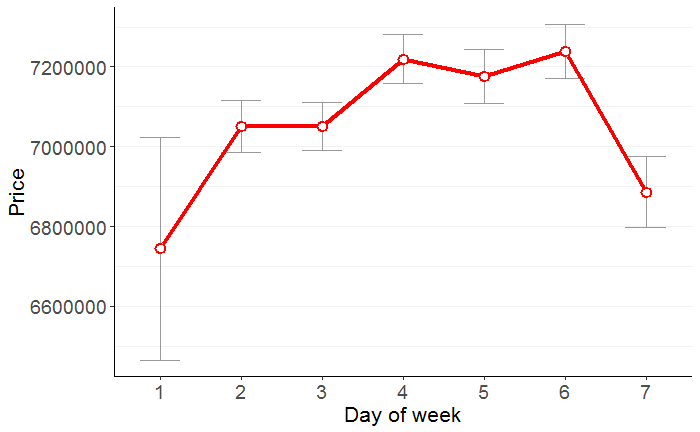

### Total Area

#### Complete (with Outliers)

It is obvious that there is an outlier here regarding the total area. I would definitely remove/recode this value.

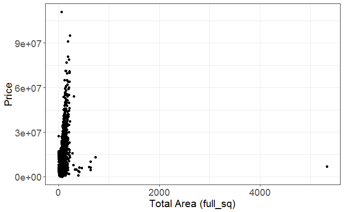

#### Zoom

Zooming in shows a clear relation, as expected, between the total area and the sale price: The bigger the appartment the higher the sale price. Quite obvious.

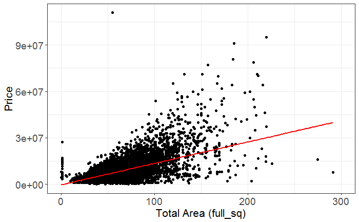

### Living Area

#### Complete (with Outliers)

It is obvious that there is an outlier here regarding the living area. I would definitely remove/recode this value.

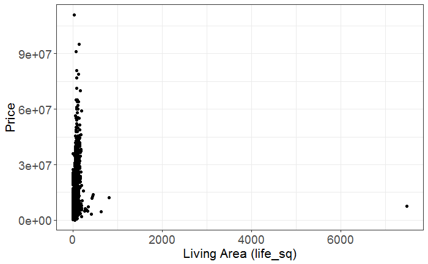

#### Zoom

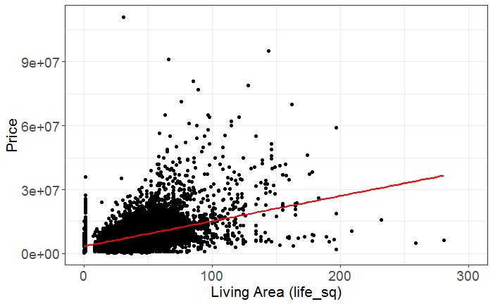

### Kitchen Area

#### Complete (with Outliers)

Again there are some outliers in kitchen area: Some of them look like years (1970, 1974, 2013, 2014) :-).

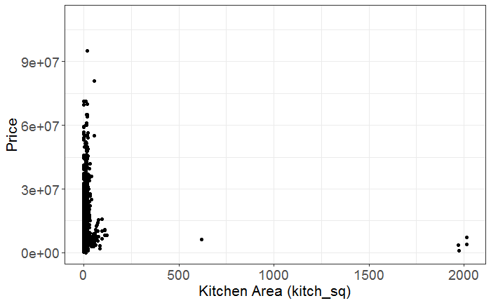

#### Zoom

Again a positive correlation between area and sale price.

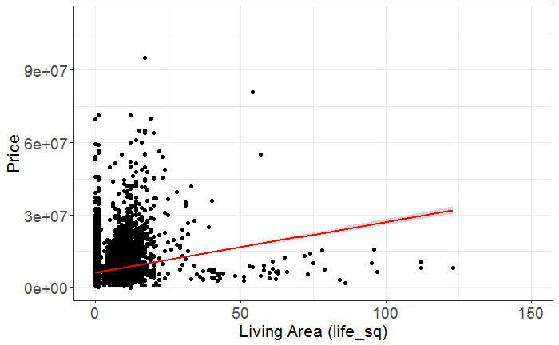

### Number of Living Rooms

The higher the number of living rooms, the higher sale prices are.

#### Complete (with Outliers)

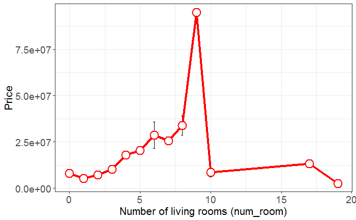

#### Zoom

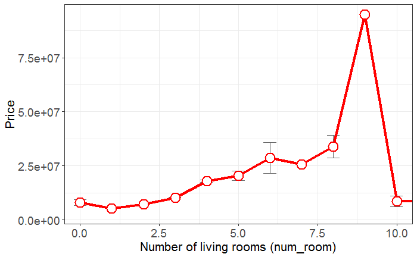

### Build Year

The build_year variable will need some cleaning, because several values don’t make sense. E.g. there are a lot of build_years with 0 and 1. And on the other hand there are some obvious mistakes, such as 20052009).

#### from 1900

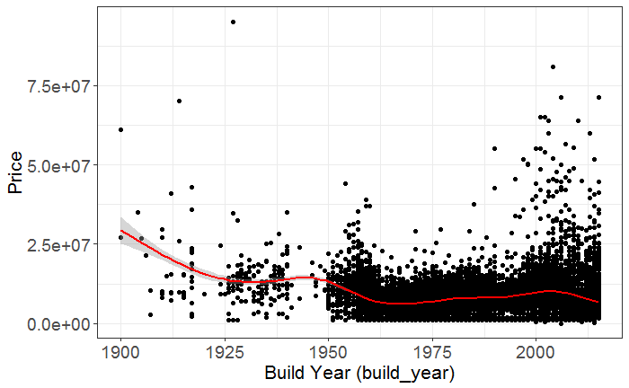

#### from 1950

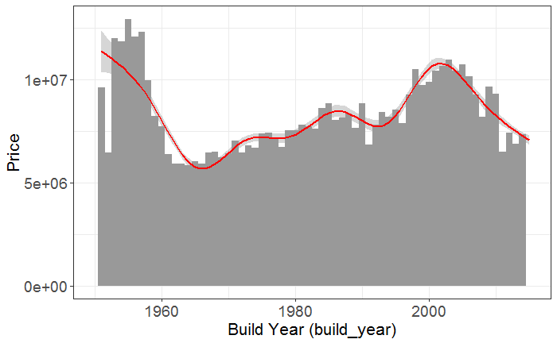

#### Build year 0 and 1

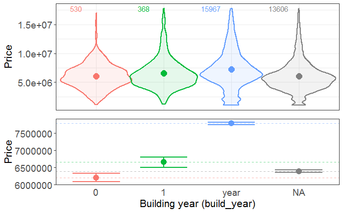

### Floor

#### Complete (with outliers)

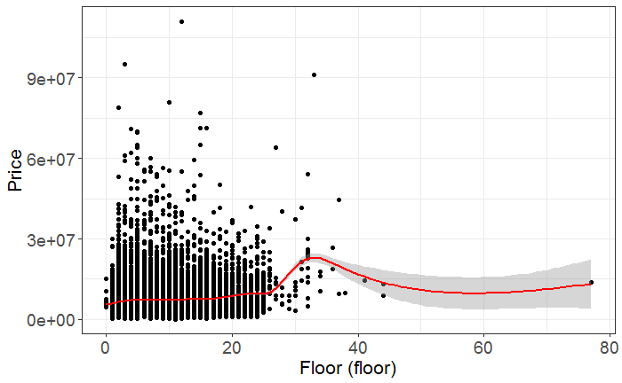

#### Zoom

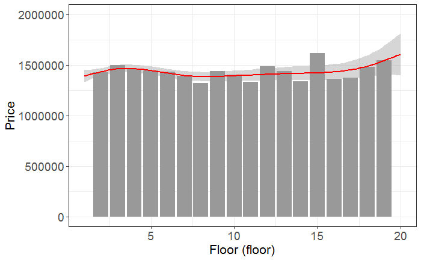

### Max Floor

#### Complete (with Outliers)

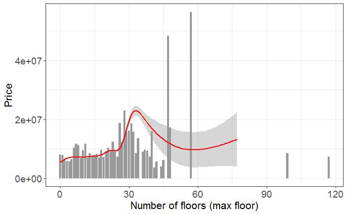

#### Zoom

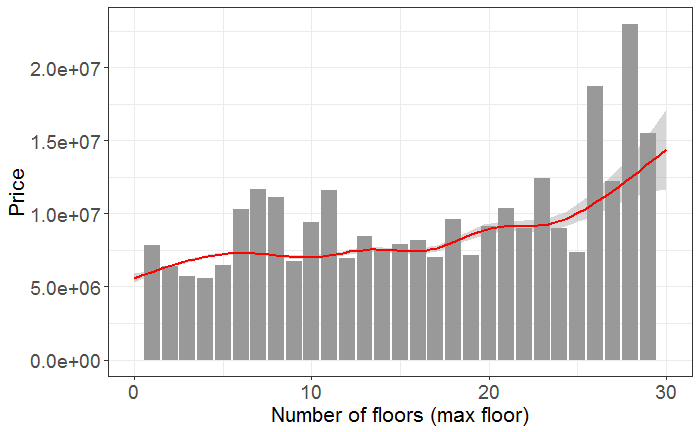

### Floor by MaxFloor

Not only the absolute floor level might have an effect on the sale price, but also the relative floor within a building. Living on the 3rd floor could be different depending if there are 20 floors above you or you can have a coffee on the rooftop :-)

#### Complete

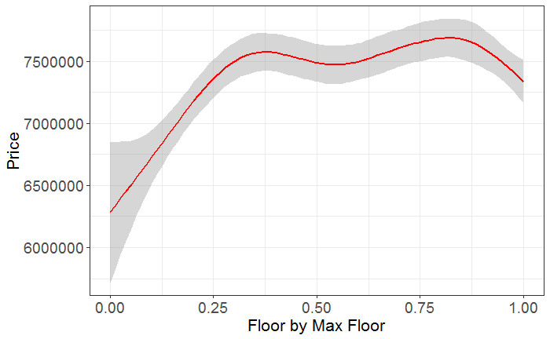

### Appartment State

This variable is coded a little counterintuitively in the data dictionary (1 - worst condition, 4 - best condition)

#### Complete

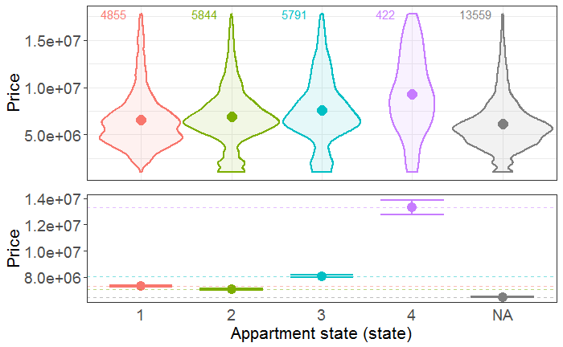

#### Interaction with build_year

There is an interesting interaction between the state of a house and its build_year. For the state variable there are many missing values for OwnerOccupier houses. So I just plot the trend for Investment houses. It is interesting to see that for houses built around 2001 there is an increase in sale price if the house is currently in the best state (4) or in a not so good state (1)

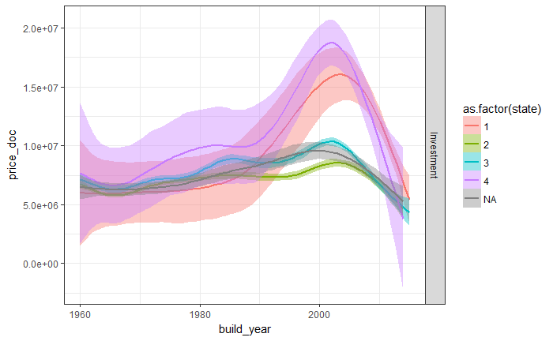

### Wall Material

The data dictionary does not contain more information about the meaning of the individual values. But still there is some variation with sale price.

#### Complete

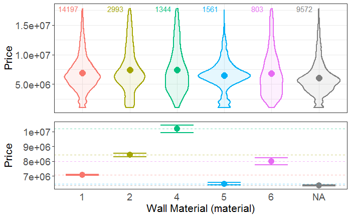

### Renovated houses

One factor affecting house prices is whether the building has been modernized. To see whether we can get this information for some of the houses I examined the Wall Material by Build Year. One can then examine whether houses with an old build year have a “modern” build material (e.g. 4 or 6). However, looking at the graph this is not/rarely the case.

#### Density

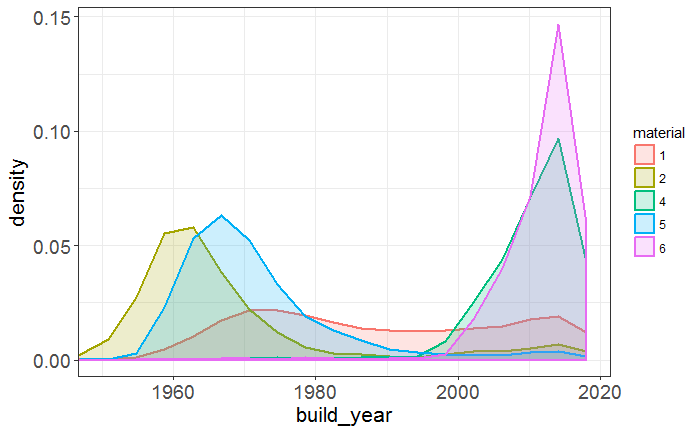

#### Proportions

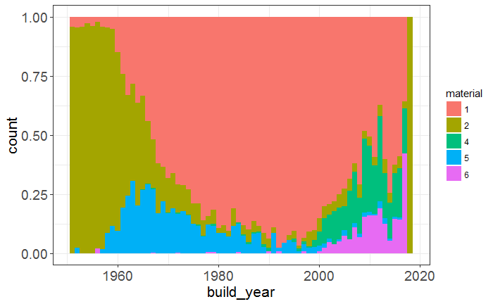